# Practical 7

### Required packages

```r
library("lme4")
```

### Load data

```r
load("~/GitHub/Advanced-Regression/Module_Data.Rdata")
```

## Multilevel models - ‘Angels of death’

Again using the data on angels of death:

```r
angel$Killer_ID <- factor(angel$Killer_ID)
angel[1:7,]
```

```
  Killer_ID       Killer Killer_Sex Cooling Vic_Number Vic_Age Vic_Sex
1         1 Annie Wilkes     Female      16          1      62  Female
2         1 Annie Wilkes     Female      13          2      80    Male
3         1 Annie Wilkes     Female      13          3      84  Female
4         1 Annie Wilkes     Female      13          4      74  Female
5         1 Annie Wilkes     Female      10          5      62  Female
6         1 Annie Wilkes     Female       4          6      80    Male
7         1 Annie Wilkes     Female       7          7      84  Female
```

### Exercise 1

*Last week, you analysed the cooling-off period variable using linear regression. Given what you learned about multilevel models in Chapter 7, describe a possible problem with that analysis.*

A killer’s cooling off periods might be correlated, which violates the independence assumption of a normal linear regression model.

### Exercise 2

*Suppose that we want to use a multilevel model with cooling-off period at the response and with victims grouped by killer. Is the structure of the data hierarchical? Explain your answer.*

Yes, the data is hierarchical as each victim was killed by one killer.

### Exercise 3

*Use a random intercept model to investigate how cooling-off period depends on victim number (this can help us to learn about whether cooling-off periods tend to change as a killer becomes more experienced). Use R to estimate the parameters of that model and interpret the estimates. Calculate and interpret the ICC. Make a plot to illustrate your estimated model.*

We want to create the random intercept model:

$$Y_{ij} = \beta_0 + \beta_1 x_{ij1} + u_{0j} + \varepsilon_{ij}$$

where $Y_{ij}$ is the cooling-off period and $x_{ij1}$ is the victim number.

```r
model1 <- lmer(Cooling ~ Vic_Number + (1 | Killer), data = angel)
summary(model1)
```

```
Linear mixed model fit by REML ['lmerMod']
Formula: Cooling ~ Vic_Number + (1 | Killer)
   Data: angel

REML criterion at convergence: 273.1

Scaled residuals:
    Min      1Q  Median      3Q     Max
-2.1457 -0.5794 -0.1552  0.7505  1.7102

Random effects:
 Groups   Name        Variance Std.Dev.
 Killer   (Intercept) 151.50   12.309
 Residual              15.31    3.913
Number of obs: 45, groups:  Killer, 7

Fixed effects:
            Estimate Std. Error t value
(Intercept)  35.6198     4.8115   7.403
Vic_Number   -2.4678     0.2853  -8.649

Correlation of Fixed Effects:
           (Intr)
Vic_Number -0.221
```

$\hat{\beta}_0 \approx 35.6$ (technically the cooling off period after the 0th victim) has no meaning here.

$\hat{\beta}_1 \approx -2.5$ says that after each additional kill, the expected cooling off period decreases by around 2.5 weeks.

$\hat{\sigma}_{u0} \approx 12.3$ weeks and $\hat{\sigma}_{\varepsilon} \approx 3.9$ weeks describe the between-killer and within-killer spread in cooling-off periods, conditional on number of victims.

The estimated ICC is…

$$\rho \approx \frac{12.3^2}{12.3^2 + 3.9^2} \approx 0.9$$

… which is very high. If we know the past cooling-off periods of a killer, then their future cooling-off periods might be quite predictable.

Extracting model parameters:

```r
randomeffects <- ranef(model1)
u0 <- randomeffects$Killer$"(Intercept)"
u0
```

```
[1] -14.679506  20.846977  -3.544748 -11.440553   7.077377   5.753930  -4.013476
```

```r
beta0 <- model1@beta[1]
beta1 <- model1@beta[2]
beta0; beta1
```

```
[1] 35.61984
```

```
[1] -2.467814
```

Plotting the model:

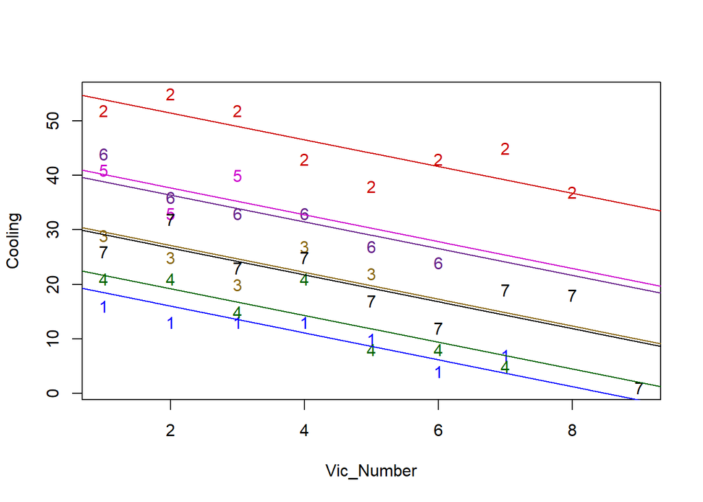

```r
colours <- c("blue", "red3", "goldenrod4", "darkgreen","magenta3", "darkorchid4", "black")

plot(Cooling ~ Vic_Number, data = angel,
     col = colours[Killer_ID],
     pch = as.character(Killer_ID))

for(j in 1:7){
  abline(a = beta0 + u0[j], b= beta1, col = colours[j])
}
```

### Exercise 4

*How could you use plots of the residuals (estimated random errors and estimated random effects) to check the normality assumptions? Use the functions* `ranef()` *and* `resid()` *to get the residuals. Make the residual plots and interpret them.*

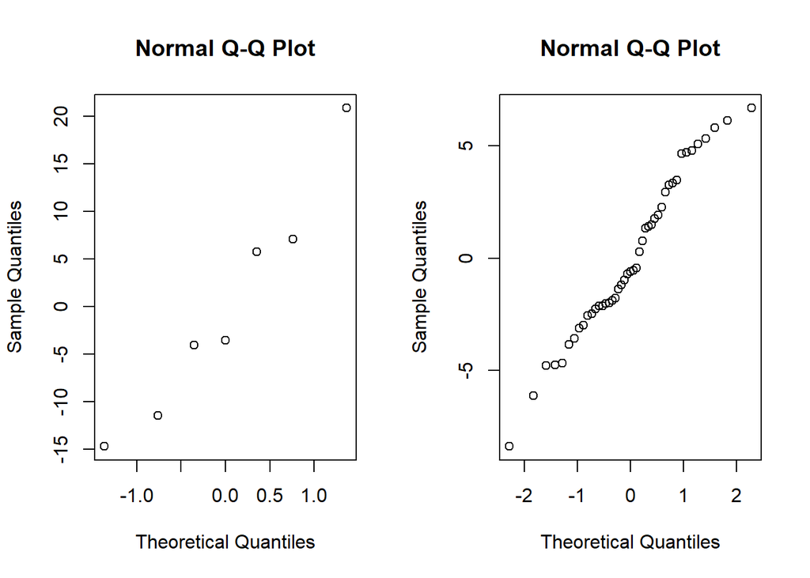

```r
epsilon <- resid(model1)
par(mfrow = c(1,2))
qqnorm(u0)
qqnorm(epsilon)
```

Looking at these plots the normality assumptions seem reasonable.

## Multilevel models - drug trial

Using the drug trial dataset:

```r
trial$hospital <- factor(trial$hospital)
trial$drug <- factor(trial$drug)

trial[1:4,]
```

```
  hospital age drug  QoL
1        1   5    A 72.0
2        1 -10    B 68.8
3        1  10    B 60.4
4        1 -20    A 81.3
```

### Exercise 5

*Draw the figure from the random slope example in the lecture notes by adapting the code from the random intercept example in the lecture notes.*

We want to plot the random slope model:

$$Y_{ij} = (\beta_0 + u_{0j}) + (\beta_1 + u_{1j}) x_{ij1} + \beta_2 x_{ij2} + \varepsilon_{ij}$$

where $Y_{ij}$ is the quality of life of a patient, $x_{ij1}$ is the age of the patient and $x_{ij2}$ is a dummy variable indicating which drug the patient took.

```r
model2 <- lmer(QoL ~ age + drug + (1 + age | hospital), data = trial)

randomeffects <- ranef(model2)
u0 <- randomeffects$hospital$"(Intercept)"
u1 <- randomeffects$hospital$"age"

beta0 <- model2@beta[1]
beta1 <- model2@beta[2]
beta2 <- model2@beta[3]
```

Creating the plot:

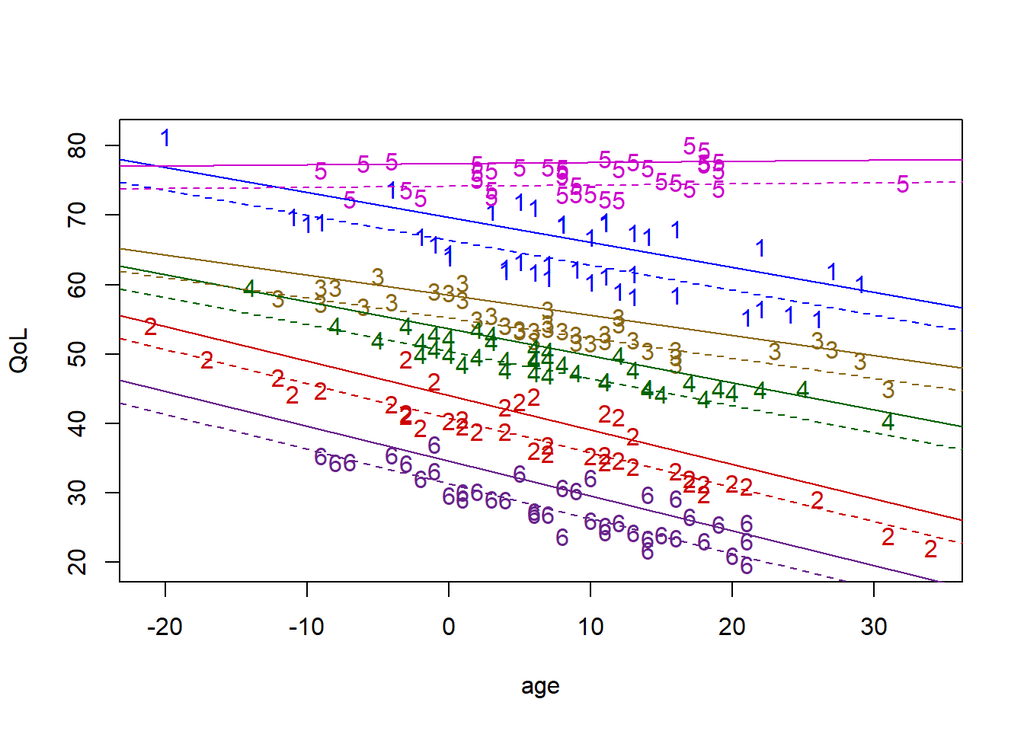

```r
colours <- c("blue", "red3", "goldenrod4", "darkgreen","magenta3", "darkorchid4")

par(mfrow = c(1,1))
plot(QoL ~ age, data = trial,
     col = colours[hospital],
     pch = as.character(hospital))

for(j in 1:6){ # regression line for drug A - solid line
  abline(a = beta0 + u0[j], b = beta1 + u1[j], col = colours[j])
}

for(j in 1:6){ # regression line for drug B - dotted line
  abline(a = beta0 + beta2 + u0[j], b = beta1 + u1[j], col = colours[j], lty = 2)
}
```

### Exercise 6

*Suppose we change our model by running the following code:*

```r
model3 <- lmer(QoL ~ age + drug + (1 + drug | hospital), data = trial)
```

*Write down this new model in clear mathematical notation. How do we interpret the random effects in this model? Make a plot that illustrates this new model.*

This code represents the random slope model:

$$Y_{ij} = (\beta_0 +u_{0j}) + \beta_1 x_{ij1} + (\beta_2 + u_{1j}) x_{ij2} + \varepsilon_{ij}$$

Extracting parameters:

```r
randomeffects <- ranef(model3)
u0 <- randomeffects$hospital$"(Intercept)"
u1 <- randomeffects$hospital$"drug"

beta0 <- model3@beta[1] # intercept
beta1 <- model3@beta[2] # age
beta2 <- model3@beta[3] # drug (random)
```

The random effect in this model allows the effect of the drug to vary randomly - this is a random **slope** model yet the regression lines will have the same slope.

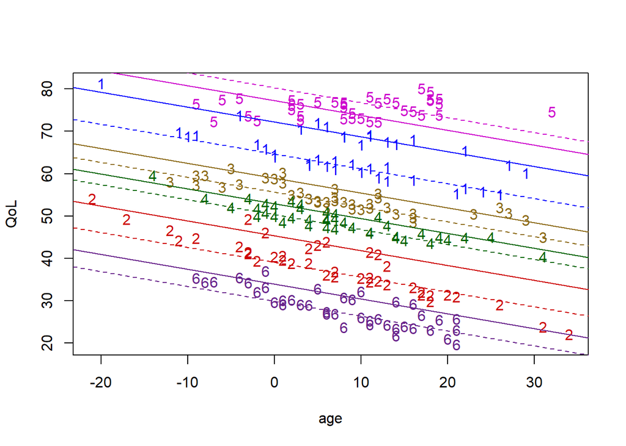

```r
plot(QoL ~ age, data = trial,
     col = colours[hospital],
     pch = as.character(hospital))

for(j in 1:6) { # regression line for drug A - solid line
  abline(a = beta0 + u0[j], b = beta1, col = colours[j])
}

for(j in 1:6) { # regression line for drug B - dotted line
  abline(a = beta0 + u0[j] + beta2 + u1[j], b = beta1, col = colours[j], lty = 2)
  }
```